# Lecture 16: Introduction to Ordinary Least Squares Regression

# Linear Regression - Ordinary Least Squares Regression

$y = \alpha + \beta X + \epsilon$

- What is the purpose of regression?
- What is required to do OLS?
- How does OLS work?

$$\\[5in]$$

## What is the purpose of regression?

$y = \alpha + \beta X + \epsilon$

- To mathematically establish the relationship between our X and Y variables.

$$\\[5in]$$

## What is the purpose of regression?

$y = \alpha + \beta X + \epsilon$

- To mathematically establish the relationship between our X and Y variables.
- To draw a line.

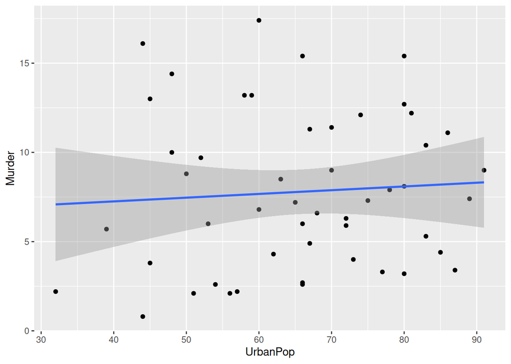

$$\\[5in]$$

## What is the purpose of regression?

$y = \alpha + \beta X + \epsilon$

- To mathematically establish the relationship between our X and Y variables.
- To draw a line.
- To reveal our expectation of Y given X

$y = \alpha + \beta X + \epsilon$ is our abstract model

Technically, regression gives us:

$E[y] = \alpha + \beta X + \epsilon$

where E[y] is our expectation of y given X.

$$\\[5in]$$

## What is required to do OLS?

$y = \alpha + \beta X + \epsilon$

### The Four (five, seven?) assumptions of linear regression

1. Linearity
2. Normality
3. Independence
4. Homoskedasticity

Two are arguably consequences of the others

5. Mean error is zero
6. Error term observations are independent

The last doesn’t matter for single X variable

7. No perfect multicollinearity

$$\\[5in]$$

## What is required to do OLS?

$y = \alpha + \beta X + \epsilon$

1. Linearity - X and Y have a linear relationship.

$$\\[5in]$$

## What is required to do OLS?

### The Assumptions of Linear Regression

$y = \alpha + \beta X + \epsilon$

1. Linearity - X and Y have a linear relationship.
2. Normality - For any value of X, Y is normally distributed.

   ```
            + We're in a random world
            + So, X won't predict Y with precision
            + X should predict Y according to a random, normal distribution
   ```

$$\\[5in]$$
### The Assumptions of Linear Regression

$y = \alpha + \beta X + \epsilon$

1. Linearity - X and Y have a linear relationship.
2. Normality - For any value of X, Y is normally distributed.
3. Independence - The observations are independent of each other.

$$\\[5in]$$

### The Assumptions of Linear Regression

$y = \alpha + \beta X + \epsilon$

1. Linearity - X and Y have a linear relationship.
2. Normality - errors are normally distributed.
3. Independence - The observations are independent of each other.
4. Homoskedasticity - The variance of the residual ($\epsilon$) is constant.

   ```
            + The error term is the same for any value of X as any other
            + 2 told us the errors are normally distributed. The variance of that distribution is independent of the value of X.
            + The opposite of homoskedasticity is heteroskedasticity and it is bad
   ```

$$\\[5in]$$

### Assumptions of Linear Regression

$y = \alpha + \beta X + \epsilon$

1. Linearity - X and Y have a linear relationship.
2. Normality - errors are normally distributed.
3. Independence - The observations are independent of each other.
4. Homoskedasticity - The variance of the residual ($\epsilon$) is constant.

## You may hear about the Gaussian assumptions of OLS

- Gaussian is another word for the normal distribution
- The normality assumption and homoskedasticity assumption aren’t necessary to fit a line
- The normality assumption **is necessary** to prove that the OLS method is the most efficient, unbiased estimator of the line
- This has been mathematically proven as well as confirmed by simulation

$$\\[5in]$$

What if the assumptions are violated?

Linearity - we can’t draw a line without doing other things. Independence - Have to account for whatever is causing the lack of independence. Homoskedasticity - The precision of the estimates decreases. Normality - The statistical tests are called into question.

These are all fixable in many cases, some fairly simply.

## How does OLS work?

$y = \alpha + \beta X + \epsilon$

### Ordinary Least Squares Regression

- This is another case of squared differences:

  ```
    + We did squared differences from the mean to get variance
    + We used squared differences in the $X^2$ test
  ```

- The differences in this case are the distance between the actual data points and the predicted location of Y based on X.
- OLS is the method that minimizes the sum of the squared distances - the method of *least squares*
- There are formulas to find it by hand:

DON’T PANIC!

$$\\[5in]$$

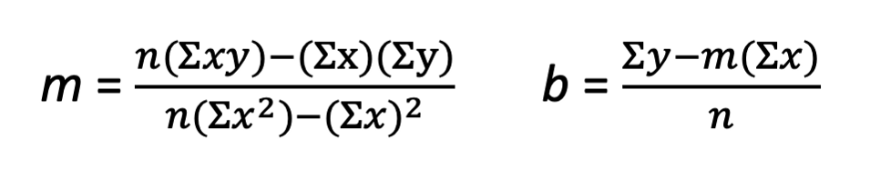

Regression formula

$$\\[5in]$$

DON’T PANIC!

There is a “simpler” way to find a regression line that uses the correlation coefficient. But if you had to find the correlation coefficient by hand, you’d have to use this formula:

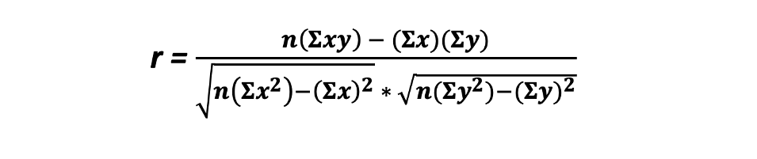

correlation coefficient formula

$$\\[5in]$$

DON’T PANIC!

I’m not asking you do any of that.

It is worth looking at the formulas all together to see some of the relationship:

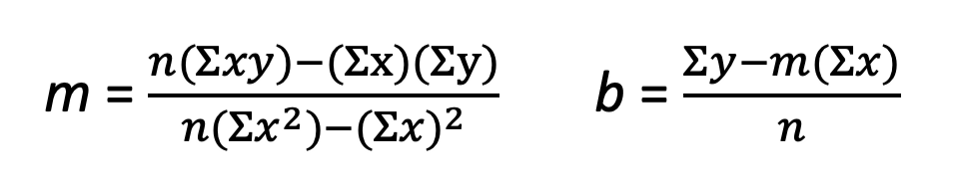

Regression formula

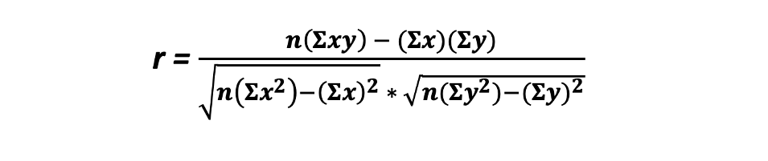

correlation coefficient formula